# Lab sessions 2 - Bayesian Statistics

April, 12 2019

**1** In each of the following cases, construct an *Accept–Reject* algorithm, generate a sample of the corresponding random variables, and draw the density function on top of the histogram. Compute the acceptance probability.

- A-R algorithm:
  - Generate $Y \sim g$, with $g$ candidate density, and, independently, $U \sim U_{[0,1]}$;
  - Accept $X=Y$ if $U \le f(Y)/cg(Y)$, discard $Y$ and $U$ otherwise.

Remember to check that $f$ and $g$ have compatible support and that the constant $c$ is defined as

$$c : \frac{f(x)}{g(x)} \le c, \quad \forall x$$

- Generate normal random variables using a Cauchy candidate in Accept–Reject algorithm.

```r
set.seed(123)
c <- optimize(f=function(x){dnorm(x,0,1)/dcauchy(x,0,1)},maximum=T,
              interval=c(-6,6))$objective
c
```

```
## [1] 1.520347
```

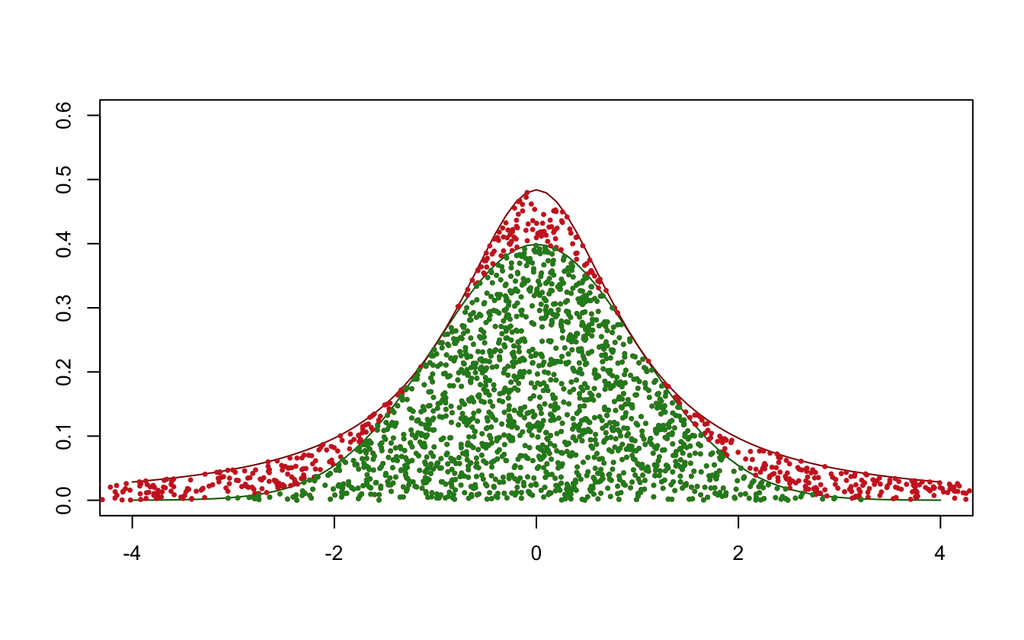

```r
xl <- c(-4,4)
yl <- c(0,.6)
plot(seq(-4,4,by=.1),dnorm(seq(-4,4, by=.1)),
     type="l", xlim=xl, ylim=yl,
     xlab="", ylab="", col="darkgreen")
lines(seq(-4,4,by=.1),c*dcauchy(seq(-4,4, by=.1)),
      col="red4")

Nsim <- 2500
u <- runif(Nsim, max=c)
y <- rcauchy(Nsim)
x <- y[u<dnorm(y)/dcauchy(y)]
points(y,u*dcauchy(y),pch=19,cex=.4, col="firebrick3")
points(x,u[u<=(dnorm(y)/(dcauchy(y)))]*dcauchy(x),
       pch=19,cex=.4,col="forestgreen")
```

```r
##acc prob
1/c
```

```
## [1] 0.6577446
```

- Generate gamma $\mathcal{G}(4.3, 6.2)$ random variables using a gamma $\mathcal{G}(4, 7)$ candidate.

```r
set.seed(123)
c <- optimize(f=function(x){dgamma(x,4.3,6.2)/dgamma(x,4,7)},maximum=T,
              interval=c(0,2))$objective
c
```

```
## [1] 4.395428
```

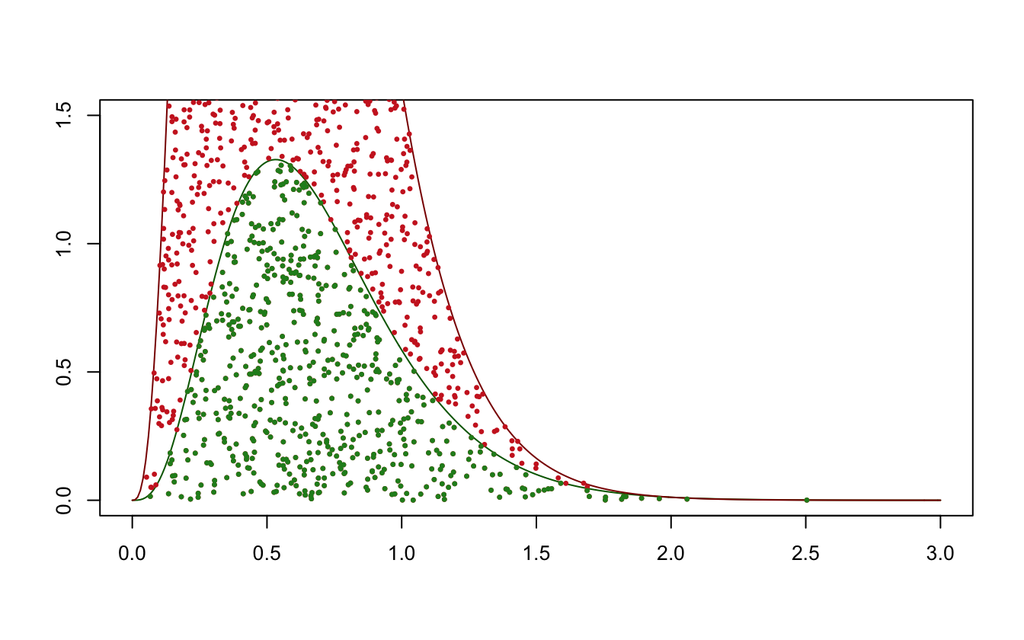

```r
xl <- c(0,3)
yl <- c(0,1.5)
plot(seq(0,3,by=.01),dgamma(seq(0,3, by=.01),4.3,6.2),
     type="l", xlim=xl, ylim=yl,
     xlab="", ylab="", col="darkgreen")
lines(seq(0,3,by=.01),c*dgamma(seq(0,3, by=.01),4,7),
      col="red4")

Nsim <- 2500
u <- runif(Nsim, max=c)
y <- rgamma(Nsim, 4,7)
x <- y[u<dgamma(y,4.3,6.2)/dgamma(y,4,7)]
points(y,u*dgamma(y,4,7),pch=19,cex=.4, col="firebrick3")
points(x,u[u<=(dgamma(y,4.3,6.2)/dgamma(y,4,7))]*dgamma(x,4,7),
       pch=19,cex=.4,col="forestgreen")
```

```r
##acc prob
1/c
```

```
## [1] 0.2275091
```

**2** Student’s $t$ density with $\nu$ degrees of freedom, is given by

$$f(x|\nu)= \frac{\Gamma\left(\frac{\nu+1}{2}\right)}{\Gamma\left(\frac{\nu}{2}\right)} \frac{1}{\sqrt{\nu \pi}}(1+x^2/\nu)^{(\nu+1)/2}$$

Calculate the mean of a t distribution with $\nu = 4$ degrees of freedom using a Metropolis–Hastings algorithm with candidate density

- $N(0,1)$
- $t$ with $\nu= 2$ degrees of freedom.

Monitor the convergence across iterations and compute the acceptance rate. Note that in both cases we are dealing with:

- Independent Metropolis-Hastings algorithm:
  - Initialize $y^{(0)}$
  - For S iterations repeat the following steps
  - At time $s$, generate a candidate $y^*$ from the proposal distribution $g(y^{*})$.
  - Compute the acceptance probability as
    $$\rho(x^{(s-1)},y^*)=\min\left(1, \frac{\pi(y^*)g(x^{(s-1)})}{\pi(x^{(s-1)})g(y^*)}\right)$$
  - Generate $U \sim U(0,1)$: if $U < \rho(x^{(s-1)},y^*)$, then $x^{(s)}=y^*$, otherwise $x^{(s)}=x^{(s-1)}$.

Note that the proposal distribution at time $s$ does not depend on the value of the chain at time $s-1$ and that the ratio of proposal distributions in the acceptance ratio does not simplify.

- $N(0,1)$

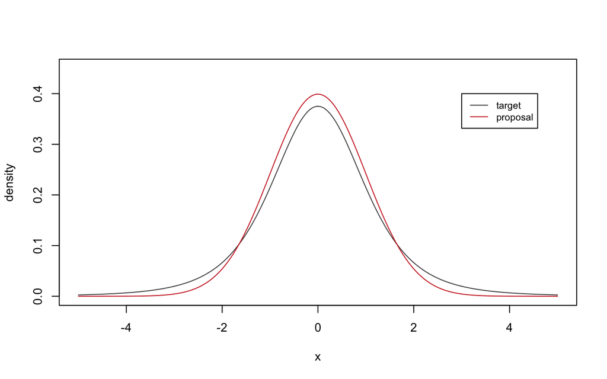

```r
set.seed(123)

Nsim <- 10^4
df <- 4
mh <- c()
mh[1] <- rnorm(1)
acc.rate <- 0
for(s in 2:Nsim){
    proposal <- rnorm(1)
    alpha.p <- min(1, (dt(proposal, df)*dnorm(mh[s-1]))/(dt(mh[s-1],df)*dnorm(proposal)))
    if(runif(1)<alpha.p){
        mh[s] <- proposal
        acc.rate <- acc.rate+1
    }else{
        mh[s]=mh[s-1]
    }
}
```

```r
mean(mh)
```

```
## [1] -0.03735362
```

```r
acc.rate/Nsim
```

```
## [1] 0.9099
```

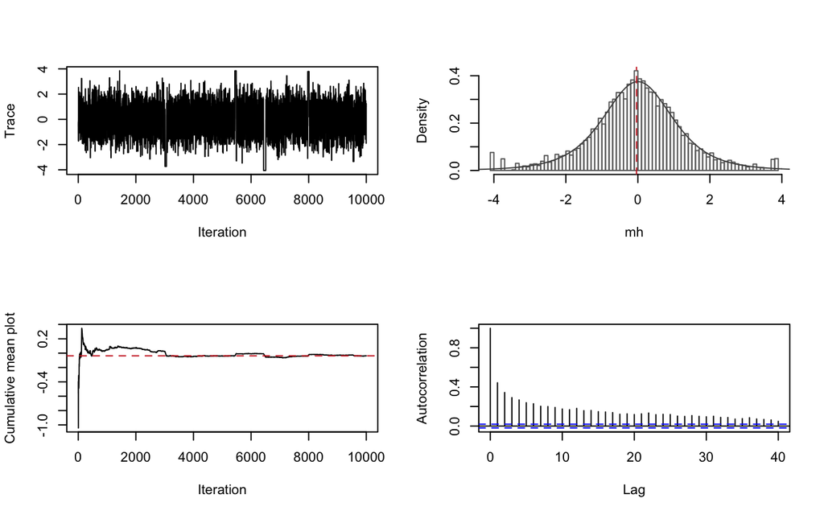

```r
##traceplot
par(mfrow=c(2,2))
plot(mh, type="l", ylab="Trace", xlab="Iteration")
##histogram
hist(mh, breaks=100, border="gray40",freq=F, main="")
lines(seq(-5,5, by=0.01), dt(seq(-5,5, by=0.01),4),type="l", col="gray30")
abline(v=mean(mh), col="firebrick3", lty=2)
##cumulative mean
a <- cumsum(mh)/1:Nsim
plot(a, type="l",ylab="Cumulative mean plot", xlab="Iteration")
abline(h=mean(mh), col="firebrick3", lty=2)
##autocorrelation
acf(mh, main="",ylab="Autocorrelation")
```

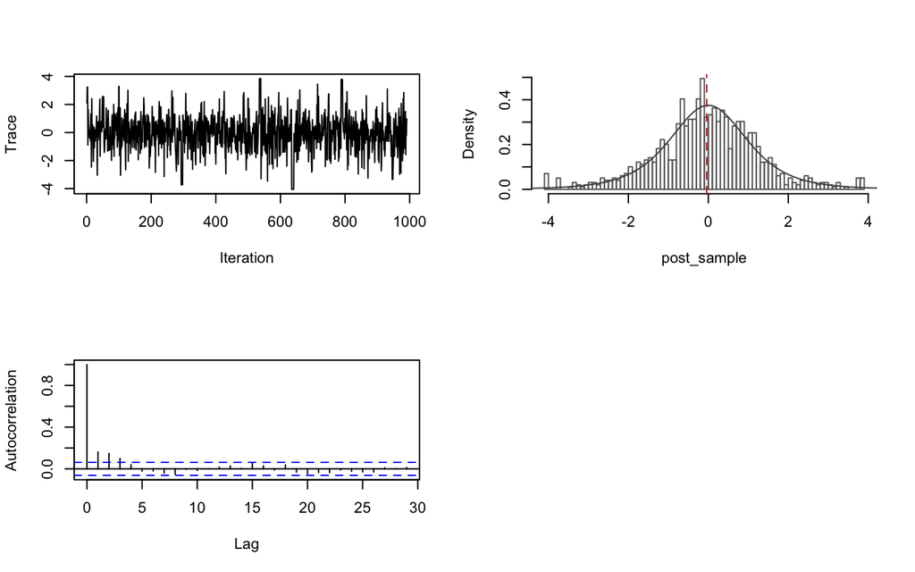

```r
##this chain sometimes stucks on some 'marginal' values, it is due to the light tails of the Normal distribution.

##burn-in and thinning
post_sample <- mh[seq(100,Nsim,by=10)]

##traceplot
par(mfrow=c(2,2))
plot(post_sample, type="l", ylab="Trace", xlab="Iteration")
##histogram
hist(post_sample, breaks=100, border="gray40",freq=F, main="")
lines(seq(-5,5, by=0.01), dt(seq(-5,5, by=0.01),4),type="l", col="gray30")
abline(v=mean(post_sample), col="firebrick3", lty=2)
##autocorrelation
acf(post_sample, main="",ylab="Autocorrelation")
```

- $t$ with $\nu= 2$ degrees of freedom.

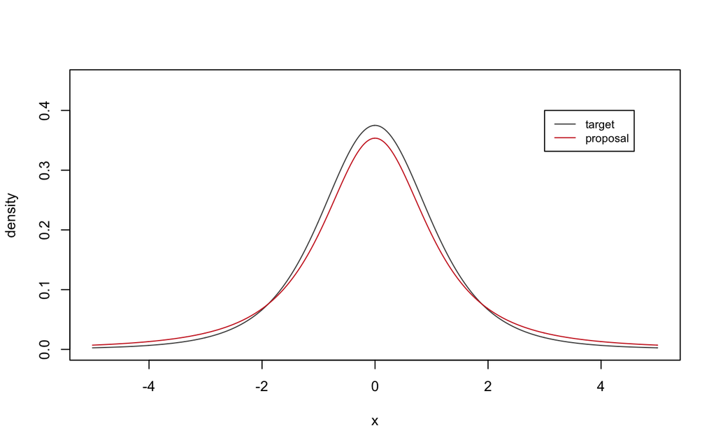

```r
mh <- c()
mh[1] <- rnorm(1)
acc.rate <- 0
for(s in 2:Nsim){
    proposal <- rt(1,2)
    alpha.p <- min(1, (dt(proposal,df)*dt(mh[s-1],2))/(dt(mh[s-1],df)*dt(proposal,2)))
    if(runif(1)<alpha.p){
        mh[s] <- proposal
        acc.rate <- acc.rate+1
    }else{
        mh[s]=mh[s-1]
    }
}
```

```r
mean(mh)
```

```
## [1] 0.02742977
```

```r
acc.rate/Nsim
```

```
## [1] 0.9177
```

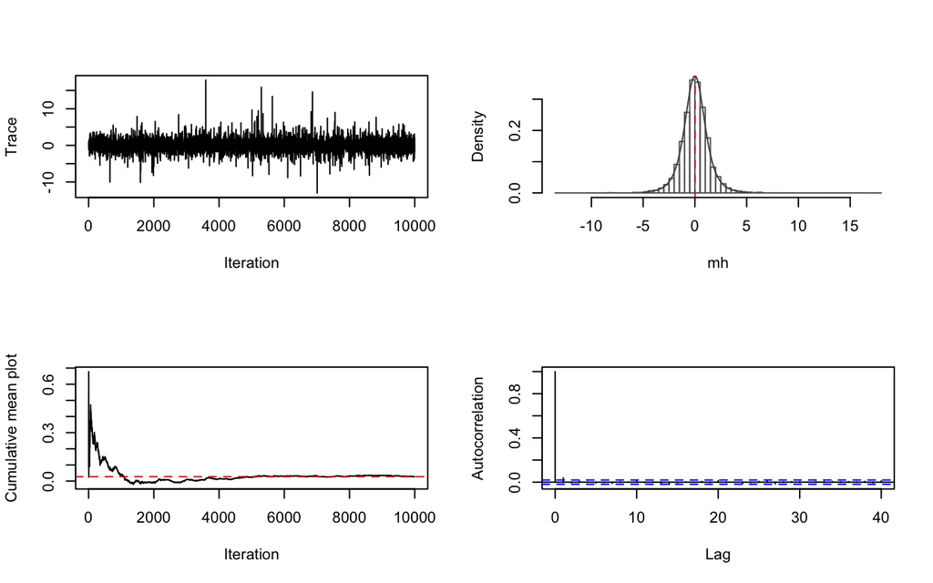

```r
##traceplot
par(mfrow=c(2,2))
plot(mh, type="l", ylab="Trace", xlab="Iteration")
##histogram
hist(mh, breaks=100, border="gray40",freq=F, main="")
lines(seq(-5,5, by=.01), dt(seq(-5,5, by=.01),4),type="l", col="gray30")
abline(v=mean(mh), col="firebrick3", lty=2)
##cumulative mean
a <- cumsum(mh)/1:Nsim
plot(a, type="l",ylab="Cumulative mean plot", xlab="Iteration")
abline(h=mean(mh), col="firebrick3", lty=2)
##autocorrelation
acf(mh, main="",ylab="Autocorrelation")
```